# test-demo-MonteCarloIntegral

胡延伸PB22050983

2025-05-25

```r
install.packages("./TimesTwoRcpp_0.1.0.tar.gz", repos = NULL)
install.packages('MonteCarloIntegral_1.0.0.tar.gz', repos = NULL)
```

# 1 R 包开发

1. 使用示例函数 (PPT 第 13 页) 测试你创建的 R 包. 需要给出代码和结果.

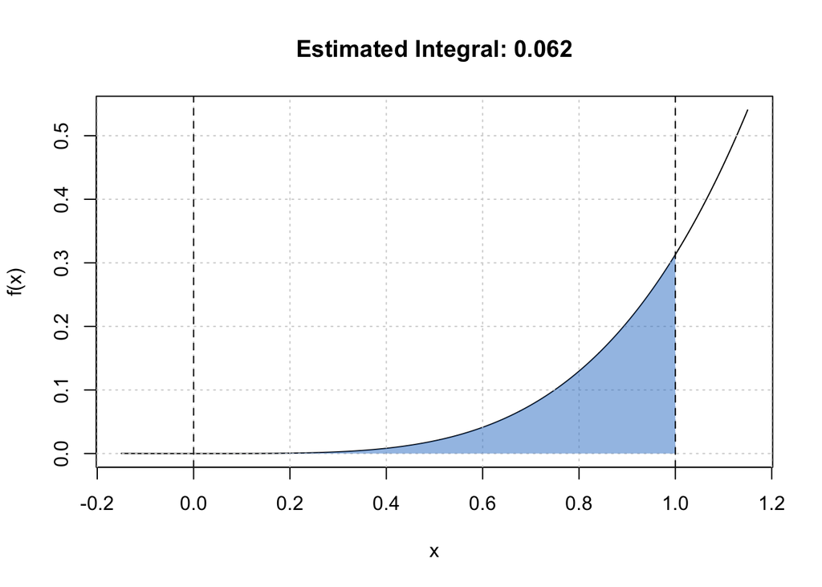

```r
library(MonteCarloIntegral)

# 示例测试
obj <- mc_int(x_range = c(0, 1), fun = "x^2*sin(x^2/pi)", B = 1e3, seed = 123)
plot(obj)
```

2. 使用你创建的 R 包估计

$$f(x)=\frac{1}{\sqrt{2 \pi}} e^{-\frac{x^2}{2}}$$

在区间 $[-2,2]$ 的积分值，并画出图像．要求在函数中设置蒙特卡洛次数为 `1e6` ，随机种子为 `15` ．

```r
# 计算积分
set.seed(15)
result <- mc_int(
  x_range = c(-2, 2),
  fun = "exp(-x^2/2)/sqrt(2*pi)",  # 正确语法
  B = 1e6,
  seed = 15
)

# 输出结果
cat("Estimated Integral:", result$I, "\n")           # 应接近 0.9544997
```

```
## Estimated Integral: 0.9544211
```

```r
cat("True Value (approx):", pnorm(2) - pnorm(-2), "\n")
```

```
## True Value (approx): 0.9544997
```

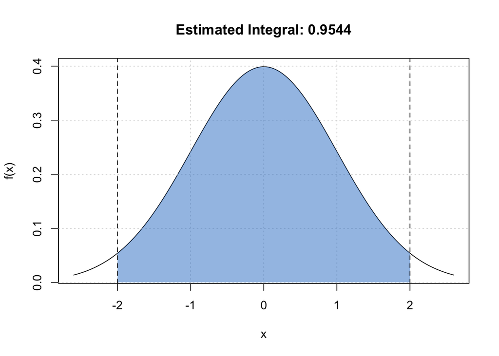

```r
# 绘图
plot(result)  # 应显示正态分布曲线和积分区域
```

# Rcpp

1．使用 Rcpp 计算向量的交错和

$$S=\sum_{k=1}^n(-1)^k x_k$$

设置随机种子为 15 ，生成 1 e 6 个服从标准正态分布 $N(0,1)$ 的样本，并计算这组样本的交错和．

```r
library(Rcpp)

# 编译Rcpp函数
sourceCpp("alternating_sum.cpp")

# 生成数据
set.seed(15)
x <- rnorm(1e6)  # 生成1e6个标准正态分布样本

# 计算交错和
result <- alternating_sum(x)

# 输出结果
cat("交错和 S =", result, "\n")
```

```
## 交错和 S = -564.9513
```

2．考虑向量 $\mathbf{x}=\left(x_1, x_2, \ldots, x_n\right), \mathbf{y}=\left(y_1, y_2, \ldots, y_m\right)$ ，定义 $\mathbf{x}$ 和 $\mathbf{y}$ 的离散卷积 $\mathbf{z}=\left(z_1, z_2, \ldots, z_{n+m-1}\right)$ 为

$$z_k=\sum_{(i, j): i+j=k} x_i y_j$$

使用 Rcpp 实现上述离散卷积运算，并计算 $(1,2,3,4,5)$ 和 $(1,2,3)$ 的离散卷积．

```r
library(Rcpp)

# 编译Rcpp函数
sourceCpp("convolve.cpp")

# 输入向量
x <- c(1, 2, 3, 4, 5)
y <- c(1, 2, 3)

# 计算离散卷积
result <- convolve_cpp(x, y)

# 输出结果
cat("离散卷积结果：", result, "\n")
```

```
## 离散卷积结果： 1 4 10 16 22 22 15
```

```r
library(Rcpp)

# 编译Rcpp函数
sourceCpp("max_row_norm.cpp")

# 输入矩阵
mat <- matrix(c(1, 2, 4, 9), nrow = 2, byrow = TRUE)
print("矩阵:")
```

```
## [1] "矩阵:"
```

```r
print(mat)
```

```
##      [,1] [,2]
## [1,]    1    2
## [2,]    4    9
```

```r
# 计算各行模的最大值
result <- max_row_norm(mat)

# 输出结果
cat("\n各行模的最大值:", result, "\n")
```

```
##
## 各行模的最大值: 9.848858
```

4．使用 Rcpp 创建如下数据框．

```
## x s
## 1 6 xyz
## 2 6 ABC
## 3 6 456
```

```r
library(Rcpp)

# 编译Rcpp函数
sourceCpp("create_dataframe.cpp")

# 生成数据框
df <- create_df()

# 输出结果
print(df)
```

```
##   x   s
## 1 6 xyz
## 2 6 ABC
## 3 6 456
```

5．使用 Rcpp 实现函数

$$f(x, y)= \begin{cases}x^2, & \text { if } x<y \\ -(x-y)^2, &
\text { if } x \geqslant y\end{cases}$$

要求该函数可进行向量化运算．设置随机种子为 15 ，从均匀分布 $U(4,6)$ 中生成 10 个样本作为 $x$ ，再从均匀分布 $U(4,6)$ 中生成 10 个样本作为 $y$ ，计算这 10 组 $(x, y)$ 在该函数下的值．

```r
library(Rcpp)

# 编译Rcpp函数
sourceCpp("f_xy.cpp")

# 生成数据
set.seed(15)
x <- runif(10, min = 4, max = 6)
y <- runif(10, min = 4, max = 6)

# 计算函数值
result <- f_xy(x, y)

# 输出结果
cat("x:", round(x, 4), "\n")
```

```
## x: 5.2042 4.3901 5.9329 5.3018 4.7341 5.9777 5.6304 4.5079 5.3745 5.6629
```

```r
cat("y:", round(y, 4), "\n")
```

```
## y: 4.2093 5.2923 5.0182 5.4133 5.7246 5.6836 4.8949 5.9293 4.2824 5.5534
```

```r
cat("f(x, y):", round(result, 4), "\n")
```

```
## f(x, y): -0.9898 19.2729 -0.8367 28.1092 22.4121 -0.0865 -0.541 20.3215 -1.1927 -0.012
```

6．使用 Rcpp，并利用均匀分布进行蒙特卡洛积分，估计

$$f(x)=\frac{1}{\sqrt{2 \pi}} e^{-\frac{x^2}{2}}$$

在任意有限区间上的积分值．设置蒙特卡洛次数为 1 e 6 ，随机种子为 15 ，估计该函数在区间 $[-2,2]$ 上的积分．注：在 Rcpp 中可使用 M＿PI 表示 $\pi$ ．

```r
library(Rcpp)

# 编译Rcpp函数
sourceCpp("monte_carlo_integral.cpp")

# 计算积分
set.seed(15)  # 额外设置种子（可选，函数内部已设置）
result <- monte_carlo_integral(a = -2, b = 2, B = 1e6, seed = 15)

# 输出结果
cat("蒙特卡洛估计值:", result, "\n")
```

```
## 蒙特卡洛估计值: 0.9544211
```

```r
cat("理论值 (pnorm(2) - pnorm(-2)):", pnorm(2) - pnorm(-2), "\n")
```

```
## 理论值 (pnorm(2) - pnorm(-2)): 0.9544997
```

注：此处与普通 R 包创建不同，不能删除 NAMESPACE 文件．